# Risk Factor Analysis

## Outcome Variable

**Outcome Variable:** pers_wast

## Predictor Variables

**Intervention Variable:** mage

**Adjustment Set:**

unadjusted

## Stratifying Variables

The analysis was stratified on these variable(s):

- agecat
- studyid
- country

## Data Summary

| agecat | studyid | country | mage | pers_wast | n_cell | n |
| --- | --- | --- | --- | --- | --- | --- |
| 0-24 months | ki0047075b-MAL-ED | BANGLADESH | [20-30) | 0 | 162 | 248 |
| 0-24 months | ki0047075b-MAL-ED | BANGLADESH | [20-30) | 1 | 7 | 248 |
| 0-24 months | ki0047075b-MAL-ED | BANGLADESH | <20 | 0 | 31 | 248 |
| 0-24 months | ki0047075b-MAL-ED | BANGLADESH | <20 | 1 | 4 | 248 |
| 0-24 months | ki0047075b-MAL-ED | BANGLADESH | >=30 | 0 | 42 | 248 |
| 0-24 months | ki0047075b-MAL-ED | BANGLADESH | >=30 | 1 | 2 | 248 |
| 0-24 months | ki0047075b-MAL-ED | BRAZIL | [20-30) | 0 | 127 | 217 |
| 0-24 months | ki0047075b-MAL-ED | BRAZIL | [20-30) | 1 | 1 | 217 |
| 0-24 months | ki0047075b-MAL-ED | BRAZIL | <20 | 0 | 40 | 217 |
| 0-24 months | ki0047075b-MAL-ED | BRAZIL | <20 | 1 | 0 | 217 |
| 0-24 months | ki0047075b-MAL-ED | BRAZIL | >=30 | 0 | 48 | 217 |
| 0-24 months | ki0047075b-MAL-ED | BRAZIL | >=30 | 1 | 1 | 217 |
| 0-24 months | ki0047075b-MAL-ED | INDIA | [20-30) | 0 | 165 | 239 |
| 0-24 months | ki0047075b-MAL-ED | INDIA | [20-30) | 1 | 19 | 239 |
| 0-24 months | ki0047075b-MAL-ED | INDIA | <20 | 0 | 32 | 239 |
| 0-24 months | ki0047075b-MAL-ED | INDIA | <20 | 1 | 2 | 239 |
| 0-24 months | ki0047075b-MAL-ED | INDIA | >=30 | 0 | 21 | 239 |
| 0-24 months | ki0047075b-MAL-ED | INDIA | >=30 | 1 | 0 | 239 |
| 0-24 months | ki0047075b-MAL-ED | NEPAL | [20-30) | 0 | 183 | 238 |
| 0-24 months | ki0047075b-MAL-ED | NEPAL | [20-30) | 1 | 4 | 238 |
| 0-24 months | ki0047075b-MAL-ED | NEPAL | <20 | 0 | 5 | 238 |
| 0-24 months | ki0047075b-MAL-ED | NEPAL | <20 | 1 | 0 | 238 |
| 0-24 months | ki0047075b-MAL-ED | NEPAL | >=30 | 0 | 46 | 238 |
| 0-24 months | ki0047075b-MAL-ED | NEPAL | >=30 | 1 | 0 | 238 |
| 0-24 months | ki0047075b-MAL-ED | PERU | [20-30) | 0 | 143 | 284 |
| 0-24 months | ki0047075b-MAL-ED | PERU | [20-30) | 1 | 0 | 284 |
| 0-24 months | ki0047075b-MAL-ED | PERU | <20 | 0 | 77 | 284 |
| 0-24 months | ki0047075b-MAL-ED | PERU | <20 | 1 | 1 | 284 |
| 0-24 months | ki0047075b-MAL-ED | PERU | >=30 | 0 | 63 | 284 |
| 0-24 months | ki0047075b-MAL-ED | PERU | >=30 | 1 | 0 | 284 |

[output cut: 402 more lines]

The following strata were considered:

- agecat: 0-24 months, studyid: ki0047075b-MAL-ED, country: BANGLADESH
- agecat: 0-24 months, studyid: ki0047075b-MAL-ED, country: BRAZIL
- agecat: 0-24 months, studyid: ki0047075b-MAL-ED, country: INDIA
- agecat: 0-24 months, studyid: ki0047075b-MAL-ED, country: NEPAL
- agecat: 0-24 months, studyid: ki0047075b-MAL-ED, country: PERU
- agecat: 0-24 months, studyid: ki0047075b-MAL-ED, country: SOUTH AFRICA
- agecat: 0-24 months, studyid: ki0047075b-MAL-ED, country: TANZANIA, UNITED REPUBLIC OF
- agecat: 0-24 months, studyid: ki1000108-CMC-V-BCS-2002, country: INDIA
- agecat: 0-24 months, studyid: ki1000108-IRC, country: INDIA
- agecat: 0-24 months, studyid: ki1000109-EE, country: PAKISTAN
- agecat: 0-24 months, studyid: ki1000304b-SAS-CompFeed, country: INDIA
- agecat: 0-24 months, studyid: ki1000304b-SAS-FoodSuppl, country: INDIA
- agecat: 0-24 months, studyid: ki1017093-NIH-Birth, country: BANGLADESH
- agecat: 0-24 months, studyid: ki1017093b-PROVIDE, country: BANGLADESH
- agecat: 0-24 months, studyid: ki1017093c-NIH-Crypto, country: BANGLADESH
- agecat: 0-24 months, studyid: ki1066203-TanzaniaChild2, country: TANZANIA, UNITED REPUBLIC OF
- agecat: 0-24 months, studyid: ki1101329-Keneba, country: GAMBIA
- agecat: 0-24 months, studyid: ki1112895-Guatemala BSC, country: GUATEMALA
- agecat: 0-24 months, studyid: ki1113344-GMS-Nepal, country: NEPAL
- agecat: 0-24 months, studyid: ki1119695-PROBIT, country: BELARUS
- agecat: 0-24 months, studyid: ki1126311-ZVITAMBO, country: ZIMBABWE
- agecat: 0-24 months, studyid: ki1135781-COHORTS, country: GUATEMALA
- agecat: 0-24 months, studyid: ki1135781-COHORTS, country: INDIA
- agecat: 0-24 months, studyid: ki1135781-COHORTS, country: PHILIPPINES
- agecat: 0-24 months, studyid: ki1148112-LCNI-5, country: MALAWI
- agecat: 0-24 months, studyid: kiGH5241-JiVitA-3, country: BANGLADESH
- agecat: 0-6 months, studyid: ki0047075b-MAL-ED, country: BANGLADESH
- agecat: 0-6 months, studyid: ki0047075b-MAL-ED, country: BRAZIL
- agecat: 0-6 months, studyid: ki0047075b-MAL-ED, country: INDIA
- agecat: 0-6 months, studyid: ki0047075b-MAL-ED, country: NEPAL
- agecat: 0-6 months, studyid: ki0047075b-MAL-ED, country: PERU
- agecat: 0-6 months, studyid: ki0047075b-MAL-ED, country: SOUTH AFRICA
- agecat: 0-6 months, studyid: ki0047075b-MAL-ED, country: TANZANIA, UNITED REPUBLIC OF
- agecat: 0-6 months, studyid: ki1000108-CMC-V-BCS-2002, country: INDIA
- agecat: 0-6 months, studyid: ki1000108-IRC, country: INDIA
- agecat: 0-6 months, studyid: ki1000109-EE, country: PAKISTAN
- agecat: 0-6 months, studyid: ki1017093-NIH-Birth, country: BANGLADESH
- agecat: 0-6 months, studyid: ki1017093b-PROVIDE, country: BANGLADESH
- agecat: 0-6 months, studyid: ki1017093c-NIH-Crypto, country: BANGLADESH
- agecat: 0-6 months, studyid: ki1066203-TanzaniaChild2, country: TANZANIA, UNITED REPUBLIC OF
- agecat: 0-6 months, studyid: ki1101329-Keneba, country: GAMBIA
- agecat: 0-6 months, studyid: ki1113344-GMS-Nepal, country: NEPAL
- agecat: 0-6 months, studyid: ki1119695-PROBIT, country: BELARUS
- agecat: 0-6 months, studyid: ki1126311-ZVITAMBO, country: ZIMBABWE
- agecat: 0-6 months, studyid: ki1135781-COHORTS, country: PHILIPPINES
- agecat: 0-6 months, studyid: kiGH5241-JiVitA-3, country: BANGLADESH
- agecat: 6-24 months, studyid: ki0047075b-MAL-ED, country: BANGLADESH
- agecat: 6-24 months, studyid: ki0047075b-MAL-ED, country: BRAZIL
- agecat: 6-24 months, studyid: ki0047075b-MAL-ED, country: INDIA
- agecat: 6-24 months, studyid: ki0047075b-MAL-ED, country: NEPAL
- agecat: 6-24 months, studyid: ki0047075b-MAL-ED, country: PERU
- agecat: 6-24 months, studyid: ki0047075b-MAL-ED, country: SOUTH AFRICA
- agecat: 6-24 months, studyid: ki0047075b-MAL-ED, country: TANZANIA, UNITED REPUBLIC OF
- agecat: 6-24 months, studyid: ki1000108-CMC-V-BCS-2002, country: INDIA
- agecat: 6-24 months, studyid: ki1000108-IRC, country: INDIA
- agecat: 6-24 months, studyid: ki1000109-EE, country: PAKISTAN
- agecat: 6-24 months, studyid: ki1000304b-SAS-CompFeed, country: INDIA
- agecat: 6-24 months, studyid: ki1000304b-SAS-FoodSuppl, country: INDIA
- agecat: 6-24 months, studyid: ki1017093-NIH-Birth, country: BANGLADESH
- agecat: 6-24 months, studyid: ki1017093b-PROVIDE, country: BANGLADESH
- agecat: 6-24 months, studyid: ki1017093c-NIH-Crypto, country: BANGLADESH
- agecat: 6-24 months, studyid: ki1066203-TanzaniaChild2, country: TANZANIA, UNITED REPUBLIC OF
- agecat: 6-24 months, studyid: ki1101329-Keneba, country: GAMBIA
- agecat: 6-24 months, studyid: ki1112895-Guatemala BSC, country: GUATEMALA
- agecat: 6-24 months, studyid: ki1113344-GMS-Nepal, country: NEPAL
- agecat: 6-24 months, studyid: ki1119695-PROBIT, country: BELARUS
- agecat: 6-24 months, studyid: ki1126311-ZVITAMBO, country: ZIMBABWE
- agecat: 6-24 months, studyid: ki1135781-COHORTS, country: GUATEMALA
- agecat: 6-24 months, studyid: ki1135781-COHORTS, country: INDIA
- agecat: 6-24 months, studyid: ki1135781-COHORTS, country: PHILIPPINES
- agecat: 6-24 months, studyid: ki1148112-LCNI-5, country: MALAWI
- agecat: 6-24 months, studyid: kiGH5241-JiVitA-3, country: BANGLADESH

### Dropped Strata

Some strata were dropped due to rare outcomes:

- agecat: 0-24 months, studyid: ki0047075b-MAL-ED, country: BANGLADESH
- agecat: 0-24 months, studyid: ki0047075b-MAL-ED, country: BRAZIL
- agecat: 0-24 months, studyid: ki0047075b-MAL-ED, country: INDIA
- agecat: 0-24 months, studyid: ki0047075b-MAL-ED, country: NEPAL
- agecat: 0-24 months, studyid: ki0047075b-MAL-ED, country: PERU
- agecat: 0-24 months, studyid: ki0047075b-MAL-ED, country: SOUTH AFRICA
- agecat: 0-24 months, studyid: ki0047075b-MAL-ED, country: TANZANIA, UNITED REPUBLIC OF
- agecat: 0-24 months, studyid: ki1000108-CMC-V-BCS-2002, country: INDIA
- agecat: 0-24 months, studyid: ki1000108-IRC, country: INDIA
- agecat: 0-24 months, studyid: ki1000109-EE, country: PAKISTAN
- agecat: 0-24 months, studyid: ki1000304b-SAS-CompFeed, country: INDIA
- agecat: 0-24 months, studyid: ki1000304b-SAS-FoodSuppl, country: INDIA
- agecat: 0-24 months, studyid: ki1017093-NIH-Birth, country: BANGLADESH
- agecat: 0-24 months, studyid: ki1017093b-PROVIDE, country: BANGLADESH
- agecat: 0-24 months, studyid: ki1112895-Guatemala BSC, country: GUATEMALA
- agecat: 0-24 months, studyid: ki1148112-LCNI-5, country: MALAWI
- agecat: 0-6 months, studyid: ki0047075b-MAL-ED, country: BANGLADESH
- agecat: 0-6 months, studyid: ki0047075b-MAL-ED, country: BRAZIL
- agecat: 0-6 months, studyid: ki0047075b-MAL-ED, country: INDIA
- agecat: 0-6 months, studyid: ki0047075b-MAL-ED, country: NEPAL
- agecat: 0-6 months, studyid: ki0047075b-MAL-ED, country: PERU
- agecat: 0-6 months, studyid: ki0047075b-MAL-ED, country: SOUTH AFRICA
- agecat: 0-6 months, studyid: ki0047075b-MAL-ED, country: TANZANIA, UNITED REPUBLIC OF
- agecat: 0-6 months, studyid: ki1000108-CMC-V-BCS-2002, country: INDIA
- agecat: 0-6 months, studyid: ki1000109-EE, country: PAKISTAN
- agecat: 0-6 months, studyid: ki1017093-NIH-Birth, country: BANGLADESH
- agecat: 0-6 months, studyid: ki1017093b-PROVIDE, country: BANGLADESH
- agecat: 0-6 months, studyid: ki1017093c-NIH-Crypto, country: BANGLADESH
- agecat: 0-6 months, studyid: ki1101329-Keneba, country: GAMBIA
- agecat: 0-6 months, studyid: ki1126311-ZVITAMBO, country: ZIMBABWE
- agecat: 0-6 months, studyid: kiGH5241-JiVitA-3, country: BANGLADESH
- agecat: 6-24 months, studyid: ki0047075b-MAL-ED, country: BANGLADESH
- agecat: 6-24 months, studyid: ki0047075b-MAL-ED, country: BRAZIL
- agecat: 6-24 months, studyid: ki0047075b-MAL-ED, country: INDIA
- agecat: 6-24 months, studyid: ki0047075b-MAL-ED, country: NEPAL
- agecat: 6-24 months, studyid: ki0047075b-MAL-ED, country: PERU
- agecat: 6-24 months, studyid: ki0047075b-MAL-ED, country: SOUTH AFRICA
- agecat: 6-24 months, studyid: ki0047075b-MAL-ED, country: TANZANIA, UNITED REPUBLIC OF
- agecat: 6-24 months, studyid: ki1000108-CMC-V-BCS-2002, country: INDIA
- agecat: 6-24 months, studyid: ki1000108-IRC, country: INDIA
- agecat: 6-24 months, studyid: ki1000109-EE, country: PAKISTAN
- agecat: 6-24 months, studyid: ki1000304b-SAS-CompFeed, country: INDIA
- agecat: 6-24 months, studyid: ki1000304b-SAS-FoodSuppl, country: INDIA
- agecat: 6-24 months, studyid: ki1017093-NIH-Birth, country: BANGLADESH
- agecat: 6-24 months, studyid: ki1017093b-PROVIDE, country: BANGLADESH
- agecat: 6-24 months, studyid: ki1112895-Guatemala BSC, country: GUATEMALA
- agecat: 6-24 months, studyid: ki1148112-LCNI-5, country: MALAWI

## Methods Detail

We’re interested in the causal parameters $E[Y_a]$ for all values of $a \in \mathcal{A}$. These parameters represent the mean outcome if, possibly contrary to fact, we intervened to set all units to have $A=a$. Under the randomization and positivity assumptions, these are identified by the statistical parameters $\psi_a=E_W[E_{Y|A,W}(Y|A=a,W)]$. In addition, we’re interested in the mean of $Y$, $E[Y]$ under no intervention (the observed mean). We will estimate these parameters by using SuperLearner to fit the relevant likelihood factors – $E_{Y|A,W}(Y|A=a,W)$ and $p(A=a|W)$, and then updating our likelihood fit using a joint TMLE.

For unadjusted analyses ($W=\{\}$), initial likelihoods were estimated using Lrnr_glm to estimate the simple $E(Y|A)$ and Lrnr_mean to estimate $p(A)$. For adjusted analyses, a small library containing Lrnr_glmnet, Lrnr_xgboost, and Lrnr_mean was used.

Having estimated these parameters, we will then use the delta method to estimate relative risks and attributable risks relative to a prespecified baseline level of $A$.

# Results Detail

## Results Plots

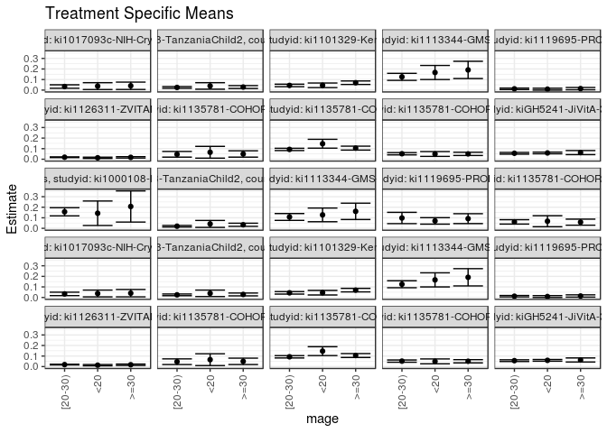

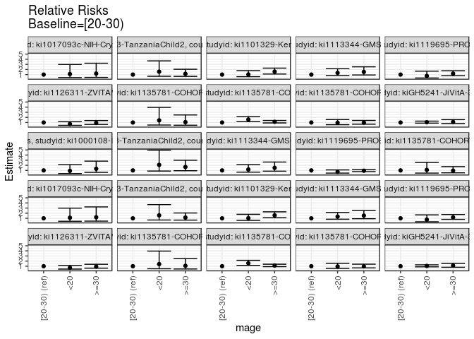

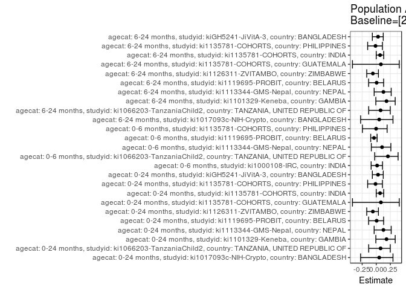

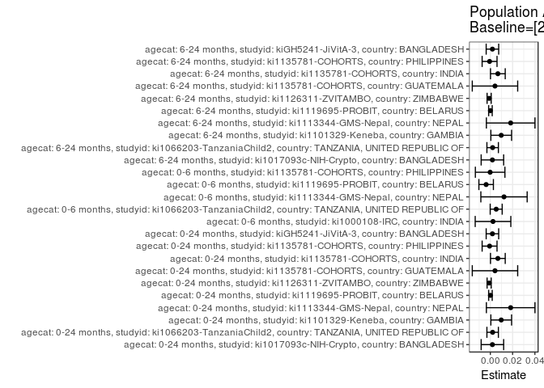

## Results Table

### Parameter: TSM

| agecat | studyid | country | intervention_level | baseline_level | estimate | ci_lower | ci_upper |
| --- | --- | --- | --- | --- | --- | --- | --- |
| 0-24 months | ki1017093c-NIH-Crypto | BANGLADESH | [20-30) | NA | 0.0337553 | 0.0174859 | 0.0500247 |
| 0-24 months | ki1017093c-NIH-Crypto | BANGLADESH | <20 | NA | 0.0375940 | 0.0052452 | 0.0699428 |
| 0-24 months | ki1017093c-NIH-Crypto | BANGLADESH | >=30 | NA | 0.0406504 | 0.0057272 | 0.0755736 |
| 0-24 months | ki1066203-TanzaniaChild2 | TANZANIA, UNITED REPUBLIC OF | [20-30) | NA | 0.0249288 | 0.0167717 | 0.0330858 |
| 0-24 months | ki1066203-TanzaniaChild2 | TANZANIA, UNITED REPUBLIC OF | <20 | NA | 0.0392157 | 0.0084514 | 0.0699799 |
| 0-24 months | ki1066203-TanzaniaChild2 | TANZANIA, UNITED REPUBLIC OF | >=30 | NA | 0.0287648 | 0.0152861 | 0.0422435 |
| 0-24 months | ki1101329-Keneba | GAMBIA | [20-30) | NA | 0.0439655 | 0.0321650 | 0.0557661 |
| 0-24 months | ki1101329-Keneba | GAMBIA | <20 | NA | 0.0451977 | 0.0235531 | 0.0668424 |
| 0-24 months | ki1101329-Keneba | GAMBIA | >=30 | NA | 0.0696133 | 0.0530292 | 0.0861973 |
| 0-24 months | ki1113344-GMS-Nepal | NEPAL | [20-30) | NA | 0.1253264 | 0.0921400 | 0.1585128 |
| 0-24 months | ki1113344-GMS-Nepal | NEPAL | <20 | NA | 0.1666667 | 0.0999309 | 0.2334024 |
| 0-24 months | ki1113344-GMS-Nepal | NEPAL | >=30 | NA | 0.1910112 | 0.1092738 | 0.2727487 |
| 0-24 months | ki1119695-PROBIT | BELARUS | [20-30) | NA | 0.0118384 | 0.0050103 | 0.0186665 |
| 0-24 months | ki1119695-PROBIT | BELARUS | <20 | NA | 0.0087829 | -0.0000427 | 0.0176085 |
| 0-24 months | ki1119695-PROBIT | BELARUS | >=30 | NA | 0.0139762 | 0.0031925 | 0.0247600 |
| 0-24 months | ki1126311-ZVITAMBO | ZIMBABWE | [20-30) | NA | 0.0189015 | 0.0155089 | 0.0222940 |
| 0-24 months | ki1126311-ZVITAMBO | ZIMBABWE | <20 | NA | 0.0134371 | 0.0074355 | 0.0194386 |
| 0-24 months | ki1126311-ZVITAMBO | ZIMBABWE | >=30 | NA | 0.0175747 | 0.0113410 | 0.0238084 |
| 0-24 months | ki1135781-COHORTS | GUATEMALA | [20-30) | NA | 0.0464135 | 0.0196034 | 0.0732236 |
| 0-24 months | ki1135781-COHORTS | GUATEMALA | <20 | NA | 0.0657895 | 0.0099984 | 0.1215806 |
| 0-24 months | ki1135781-COHORTS | GUATEMALA | >=30 | NA | 0.0497512 | 0.0196632 | 0.0798393 |
| 0-24 months | ki1135781-COHORTS | INDIA | [20-30) | NA | 0.0928023 | 0.0819307 | 0.1036740 |
| 0-24 months | ki1135781-COHORTS | INDIA | <20 | NA | 0.1465201 | 0.1045669 | 0.1884734 |
| 0-24 months | ki1135781-COHORTS | INDIA | >=30 | NA | 0.1049149 | 0.0864474 | 0.1233825 |
| 0-24 months | ki1135781-COHORTS | PHILIPPINES | [20-30) | NA | 0.0519093 | 0.0412866 | 0.0625320 |
| 0-24 months | ki1135781-COHORTS | PHILIPPINES | <20 | NA | 0.0494186 | 0.0265107 | 0.0723265 |
| 0-24 months | ki1135781-COHORTS | PHILIPPINES | >=30 | NA | 0.0505689 | 0.0352964 | 0.0658414 |
| 0-24 months | kiGH5241-JiVitA-3 | BANGLADESH | [20-30) | NA | 0.0562552 | 0.0480856 | 0.0644249 |
| 0-24 months | kiGH5241-JiVitA-3 | BANGLADESH | <20 | NA | 0.0592918 | 0.0512529 | 0.0673307 |
| 0-24 months | kiGH5241-JiVitA-3 | BANGLADESH | >=30 | NA | 0.0627306 | 0.0434465 | 0.0820148 |
| 0-6 months | ki1000108-IRC | INDIA | [20-30) | NA | 0.1568047 | 0.1179920 | 0.1956175 |
| 0-6 months | ki1000108-IRC | INDIA | <20 | NA | 0.1428571 | 0.0267838 | 0.2589305 |
| 0-6 months | ki1000108-IRC | INDIA | >=30 | NA | 0.2068966 | 0.0592812 | 0.3545119 |
| 0-6 months | ki1066203-TanzaniaChild2 | TANZANIA, UNITED REPUBLIC OF | [20-30) | NA | 0.0201794 | 0.0126432 | 0.0277156 |
| 0-6 months | ki1066203-TanzaniaChild2 | TANZANIA, UNITED REPUBLIC OF | <20 | NA | 0.0419580 | 0.0090891 | 0.0748270 |
| 0-6 months | ki1066203-TanzaniaChild2 | TANZANIA, UNITED REPUBLIC OF | >=30 | NA | 0.0337478 | 0.0188278 | 0.0486678 |
| 0-6 months | ki1113344-GMS-Nepal | NEPAL | [20-30) | NA | 0.1076487 | 0.0752868 | 0.1400106 |
| 0-6 months | ki1113344-GMS-Nepal | NEPAL | <20 | NA | 0.1274510 | 0.0626748 | 0.1922272 |
| 0-6 months | ki1113344-GMS-Nepal | NEPAL | >=30 | NA | 0.1609195 | 0.0836345 | 0.2382046 |
| 0-6 months | ki1119695-PROBIT | BELARUS | [20-30) | NA | 0.0979532 | 0.0445346 | 0.1513718 |
| 0-6 months | ki1119695-PROBIT | BELARUS | <20 | NA | 0.0704225 | 0.0398221 | 0.1010230 |
| 0-6 months | ki1119695-PROBIT | BELARUS | >=30 | NA | 0.0918699 | 0.0449882 | 0.1387516 |
| 0-6 months | ki1135781-COHORTS | PHILIPPINES | [20-30) | NA | 0.0611440 | 0.0402763 | 0.0820117 |
| 0-6 months | ki1135781-COHORTS | PHILIPPINES | <20 | NA | 0.0674157 | 0.0152924 | 0.1195391 |
| 0-6 months | ki1135781-COHORTS | PHILIPPINES | >=30 | NA | 0.0583658 | 0.0296873 | 0.0870443 |
| 6-24 months | ki1017093c-NIH-Crypto | BANGLADESH | [20-30) | NA | 0.0337553 | 0.0174859 | 0.0500247 |
| 6-24 months | ki1017093c-NIH-Crypto | BANGLADESH | <20 | NA | 0.0375940 | 0.0052452 | 0.0699428 |
| 6-24 months | ki1017093c-NIH-Crypto | BANGLADESH | >=30 | NA | 0.0406504 | 0.0057272 | 0.0755736 |
| 6-24 months | ki1066203-TanzaniaChild2 | TANZANIA, UNITED REPUBLIC OF | [20-30) | NA | 0.0249288 | 0.0167717 | 0.0330858 |
| 6-24 months | ki1066203-TanzaniaChild2 | TANZANIA, UNITED REPUBLIC OF | <20 | NA | 0.0392157 | 0.0084514 | 0.0699799 |
| 6-24 months | ki1066203-TanzaniaChild2 | TANZANIA, UNITED REPUBLIC OF | >=30 | NA | 0.0287648 | 0.0152861 | 0.0422435 |
| 6-24 months | ki1101329-Keneba | GAMBIA | [20-30) | NA | 0.0439655 | 0.0321650 | 0.0557661 |
| 6-24 months | ki1101329-Keneba | GAMBIA | <20 | NA | 0.0451977 | 0.0235531 | 0.0668424 |
| 6-24 months | ki1101329-Keneba | GAMBIA | >=30 | NA | 0.0696133 | 0.0530292 | 0.0861973 |
| 6-24 months | ki1113344-GMS-Nepal | NEPAL | [20-30) | NA | 0.1253264 | 0.0921400 | 0.1585128 |
| 6-24 months | ki1113344-GMS-Nepal | NEPAL | <20 | NA | 0.1666667 | 0.0999309 | 0.2334024 |
| 6-24 months | ki1113344-GMS-Nepal | NEPAL | >=30 | NA | 0.1910112 | 0.1092738 | 0.2727487 |
| 6-24 months | ki1119695-PROBIT | BELARUS | [20-30) | NA | 0.0118384 | 0.0050103 | 0.0186665 |
| 6-24 months | ki1119695-PROBIT | BELARUS | <20 | NA | 0.0087829 | -0.0000427 | 0.0176085 |
| 6-24 months | ki1119695-PROBIT | BELARUS | >=30 | NA | 0.0139762 | 0.0031925 | 0.0247600 |
| 6-24 months | ki1126311-ZVITAMBO | ZIMBABWE | [20-30) | NA | 0.0189015 | 0.0155089 | 0.0222940 |
| 6-24 months | ki1126311-ZVITAMBO | ZIMBABWE | <20 | NA | 0.0134371 | 0.0074355 | 0.0194386 |
| 6-24 months | ki1126311-ZVITAMBO | ZIMBABWE | >=30 | NA | 0.0175747 | 0.0113410 | 0.0238084 |
| 6-24 months | ki1135781-COHORTS | GUATEMALA | [20-30) | NA | 0.0464135 | 0.0196034 | 0.0732236 |
| 6-24 months | ki1135781-COHORTS | GUATEMALA | <20 | NA | 0.0657895 | 0.0099984 | 0.1215806 |
| 6-24 months | ki1135781-COHORTS | GUATEMALA | >=30 | NA | 0.0497512 | 0.0196632 | 0.0798393 |
| 6-24 months | ki1135781-COHORTS | INDIA | [20-30) | NA | 0.0928023 | 0.0819307 | 0.1036740 |
| 6-24 months | ki1135781-COHORTS | INDIA | <20 | NA | 0.1465201 | 0.1045669 | 0.1884734 |
| 6-24 months | ki1135781-COHORTS | INDIA | >=30 | NA | 0.1049149 | 0.0864474 | 0.1233825 |
| 6-24 months | ki1135781-COHORTS | PHILIPPINES | [20-30) | NA | 0.0519093 | 0.0412866 | 0.0625320 |
| 6-24 months | ki1135781-COHORTS | PHILIPPINES | <20 | NA | 0.0494186 | 0.0265107 | 0.0723265 |
| 6-24 months | ki1135781-COHORTS | PHILIPPINES | >=30 | NA | 0.0505689 | 0.0352964 | 0.0658414 |
| 6-24 months | kiGH5241-JiVitA-3 | BANGLADESH | [20-30) | NA | 0.0562552 | 0.0480856 | 0.0644249 |
| 6-24 months | kiGH5241-JiVitA-3 | BANGLADESH | <20 | NA | 0.0592918 | 0.0512529 | 0.0673307 |
| 6-24 months | kiGH5241-JiVitA-3 | BANGLADESH | >=30 | NA | 0.0627306 | 0.0434465 | 0.0820148 |

### Parameter: E(Y)

| agecat | studyid | country | intervention_level | baseline_level | estimate | ci_lower | ci_upper |
| --- | --- | --- | --- | --- | --- | --- | --- |
| 0-24 months | ki1017093c-NIH-Crypto | BANGLADESH | NA | NA | 0.0356164 | 0.0221630 | 0.0490699 |
| 0-24 months | ki1066203-TanzaniaChild2 | TANZANIA, UNITED REPUBLIC OF | NA | NA | 0.0270019 | 0.0201456 | 0.0338581 |
| 0-24 months | ki1101329-Keneba | GAMBIA | NA | NA | 0.0537412 | 0.0447529 | 0.0627295 |
| 0-24 months | ki1113344-GMS-Nepal | NEPAL | NA | NA | 0.1435811 | 0.1153098 | 0.1718524 |
| 0-24 months | ki1119695-PROBIT | BELARUS | NA | NA | 0.0119167 | 0.0046062 | 0.0192272 |
| 0-24 months | ki1126311-ZVITAMBO | ZIMBABWE | NA | NA | 0.0178284 | 0.0151404 | 0.0205163 |
| 0-24 months | ki1135781-COHORTS | GUATEMALA | NA | NA | 0.0505837 | 0.0316200 | 0.0695473 |
| 0-24 months | ki1135781-COHORTS | INDIA | NA | NA | 0.0995575 | 0.0903557 | 0.1087594 |
| 0-24 months | ki1135781-COHORTS | PHILIPPINES | NA | NA | 0.0512273 | 0.0430760 | 0.0593786 |
| 0-24 months | kiGH5241-JiVitA-3 | BANGLADESH | NA | NA | 0.0581335 | 0.0523249 | 0.0639422 |
| 0-6 months | ki1000108-IRC | INDIA | NA | NA | 0.1592040 | 0.1233945 | 0.1950135 |
| 0-6 months | ki1066203-TanzaniaChild2 | TANZANIA, UNITED REPUBLIC OF | NA | NA | 0.0254403 | 0.0186125 | 0.0322681 |
| 0-6 months | ki1113344-GMS-Nepal | NEPAL | NA | NA | 0.1199262 | 0.0925504 | 0.1473020 |
| 0-6 months | ki1119695-PROBIT | BELARUS | NA | NA | 0.0941866 | 0.0454872 | 0.1428859 |
| 0-6 months | ki1135781-COHORTS | PHILIPPINES | NA | NA | 0.0609613 | 0.0448957 | 0.0770269 |
| 6-24 months | ki1017093c-NIH-Crypto | BANGLADESH | NA | NA | 0.0356164 | 0.0221630 | 0.0490699 |
| 6-24 months | ki1066203-TanzaniaChild2 | TANZANIA, UNITED REPUBLIC OF | NA | NA | 0.0270019 | 0.0201456 | 0.0338581 |
| 6-24 months | ki1101329-Keneba | GAMBIA | NA | NA | 0.0537412 | 0.0447529 | 0.0627295 |
| 6-24 months | ki1113344-GMS-Nepal | NEPAL | NA | NA | 0.1435811 | 0.1153098 | 0.1718524 |
| 6-24 months | ki1119695-PROBIT | BELARUS | NA | NA | 0.0119167 | 0.0046062 | 0.0192272 |
| 6-24 months | ki1126311-ZVITAMBO | ZIMBABWE | NA | NA | 0.0178284 | 0.0151404 | 0.0205163 |
| 6-24 months | ki1135781-COHORTS | GUATEMALA | NA | NA | 0.0505837 | 0.0316200 | 0.0695473 |
| 6-24 months | ki1135781-COHORTS | INDIA | NA | NA | 0.0995575 | 0.0903557 | 0.1087594 |
| 6-24 months | ki1135781-COHORTS | PHILIPPINES | NA | NA | 0.0512273 | 0.0430760 | 0.0593786 |
| 6-24 months | kiGH5241-JiVitA-3 | BANGLADESH | NA | NA | 0.0581335 | 0.0523249 | 0.0639422 |

### Parameter: RR

| agecat | studyid | country | intervention_level | baseline_level | estimate | ci_lower | ci_upper |
| --- | --- | --- | --- | --- | --- | --- | --- |
| 0-24 months | ki1017093c-NIH-Crypto | BANGLADESH | [20-30) | [20-30) | 1.0000000 | 1.0000000 | 1.000000 |
| 0-24 months | ki1017093c-NIH-Crypto | BANGLADESH | <20 | [20-30) | 1.1137218 | 0.4153797 | 2.986127 |
| 0-24 months | ki1017093c-NIH-Crypto | BANGLADESH | >=30 | [20-30) | 1.2042683 | 0.4496864 | 3.225052 |
| 0-24 months | ki1066203-TanzaniaChild2 | TANZANIA, UNITED REPUBLIC OF | [20-30) | [20-30) | 1.0000000 | 1.0000000 | 1.000000 |
| 0-24 months | ki1066203-TanzaniaChild2 | TANZANIA, UNITED REPUBLIC OF | <20 | [20-30) | 1.5731092 | 0.6723736 | 3.680502 |
| 0-24 months | ki1066203-TanzaniaChild2 | TANZANIA, UNITED REPUBLIC OF | >=30 | [20-30) | 1.1538796 | 0.6515543 | 2.043480 |
| 0-24 months | ki1101329-Keneba | GAMBIA | [20-30) | [20-30) | 1.0000000 | 1.0000000 | 1.000000 |
| 0-24 months | ki1101329-Keneba | GAMBIA | <20 | [20-30) | 1.0280270 | 0.5937273 | 1.780008 |
| 0-24 months | ki1101329-Keneba | GAMBIA | >=30 | [20-30) | 1.5833604 | 1.1059104 | 2.266938 |
| 0-24 months | ki1113344-GMS-Nepal | NEPAL | [20-30) | [20-30) | 1.0000000 | 1.0000000 | 1.000000 |
| 0-24 months | ki1113344-GMS-Nepal | NEPAL | <20 | [20-30) | 1.3298611 | 0.8228527 | 2.149268 |
| 0-24 months | ki1113344-GMS-Nepal | NEPAL | >=30 | [20-30) | 1.5241105 | 0.9214446 | 2.520947 |
| 0-24 months | ki1119695-PROBIT | BELARUS | [20-30) | [20-30) | 1.0000000 | 1.0000000 | 1.000000 |
| 0-24 months | ki1119695-PROBIT | BELARUS | <20 | [20-30) | 0.7418998 | 0.3300901 | 1.667470 |
| 0-24 months | ki1119695-PROBIT | BELARUS | >=30 | [20-30) | 1.1805812 | 0.7970988 | 1.748556 |
| 0-24 months | ki1126311-ZVITAMBO | ZIMBABWE | [20-30) | [20-30) | 1.0000000 | 1.0000000 | 1.000000 |
| 0-24 months | ki1126311-ZVITAMBO | ZIMBABWE | <20 | [20-30) | 0.7109008 | 0.4392980 | 1.150426 |
| 0-24 months | ki1126311-ZVITAMBO | ZIMBABWE | >=30 | [20-30) | 0.9298064 | 0.6248112 | 1.383682 |
| 0-24 months | ki1135781-COHORTS | GUATEMALA | [20-30) | [20-30) | 1.0000000 | 1.0000000 | 1.000000 |
| 0-24 months | ki1135781-COHORTS | GUATEMALA | <20 | [20-30) | 1.4174641 | 0.5080398 | 3.954817 |
| 0-24 months | ki1135781-COHORTS | GUATEMALA | >=30 | [20-30) | 1.0719131 | 0.4644682 | 2.473792 |
| 0-24 months | ki1135781-COHORTS | INDIA | [20-30) | [20-30) | 1.0000000 | 1.0000000 | 1.000000 |
| 0-24 months | ki1135781-COHORTS | INDIA | <20 | [20-30) | 1.5788411 | 1.1587274 | 2.151273 |
| 0-24 months | ki1135781-COHORTS | INDIA | >=30 | [20-30) | 1.1305204 | 0.9150605 | 1.396712 |
| 0-24 months | ki1135781-COHORTS | PHILIPPINES | [20-30) | [20-30) | 1.0000000 | 1.0000000 | 1.000000 |
| 0-24 months | ki1135781-COHORTS | PHILIPPINES | <20 | [20-30) | 0.9520182 | 0.5735666 | 1.580180 |
| 0-24 months | ki1135781-COHORTS | PHILIPPINES | >=30 | [20-30) | 0.9741779 | 0.6763961 | 1.403057 |
| 0-24 months | kiGH5241-JiVitA-3 | BANGLADESH | [20-30) | [20-30) | 1.0000000 | 1.0000000 | 1.000000 |
| 0-24 months | kiGH5241-JiVitA-3 | BANGLADESH | <20 | [20-30) | 1.0539780 | 0.8742819 | 1.270608 |
| 0-24 months | kiGH5241-JiVitA-3 | BANGLADESH | >=30 | [20-30) | 1.1151071 | 0.7956617 | 1.562805 |
| 0-6 months | ki1000108-IRC | INDIA | [20-30) | [20-30) | 1.0000000 | 1.0000000 | 1.000000 |
| 0-6 months | ki1000108-IRC | INDIA | <20 | [20-30) | 0.9110512 | 0.3896386 | 2.130216 |
| 0-6 months | ki1000108-IRC | INDIA | >=30 | [20-30) | 1.3194535 | 0.6200390 | 2.807819 |
| 0-6 months | ki1066203-TanzaniaChild2 | TANZANIA, UNITED REPUBLIC OF | [20-30) | [20-30) | 1.0000000 | 1.0000000 | 1.000000 |
| 0-6 months | ki1066203-TanzaniaChild2 | TANZANIA, UNITED REPUBLIC OF | <20 | [20-30) | 2.0792541 | 0.8729867 | 4.952306 |
| 0-6 months | ki1066203-TanzaniaChild2 | TANZANIA, UNITED REPUBLIC OF | >=30 | [20-30) | 1.6723900 | 0.9375588 | 2.983160 |
| 0-6 months | ki1113344-GMS-Nepal | NEPAL | [20-30) | [20-30) | 1.0000000 | 1.0000000 | 1.000000 |
| 0-6 months | ki1113344-GMS-Nepal | NEPAL | <20 | [20-30) | 1.1839525 | 0.6559706 | 2.136900 |
| 0-6 months | ki1113344-GMS-Nepal | NEPAL | >=30 | [20-30) | 1.4948578 | 0.8482588 | 2.634337 |
| 0-6 months | ki1119695-PROBIT | BELARUS | [20-30) | [20-30) | 1.0000000 | 1.0000000 | 1.000000 |
| 0-6 months | ki1119695-PROBIT | BELARUS | <20 | [20-30) | 0.7189405 | 0.4707561 | 1.097969 |
| 0-6 months | ki1119695-PROBIT | BELARUS | >=30 | [20-30) | 0.9378959 | 0.7643033 | 1.150916 |
| 0-6 months | ki1135781-COHORTS | PHILIPPINES | [20-30) | [20-30) | 1.0000000 | 1.0000000 | 1.000000 |
| 0-6 months | ki1135781-COHORTS | PHILIPPINES | <20 | [20-30) | 1.1025734 | 0.4735529 | 2.567122 |
| 0-6 months | ki1135781-COHORTS | PHILIPPINES | >=30 | [20-30) | 0.9545626 | 0.5247893 | 1.736296 |
| 6-24 months | ki1017093c-NIH-Crypto | BANGLADESH | [20-30) | [20-30) | 1.0000000 | 1.0000000 | 1.000000 |
| 6-24 months | ki1017093c-NIH-Crypto | BANGLADESH | <20 | [20-30) | 1.1137218 | 0.4153797 | 2.986127 |
| 6-24 months | ki1017093c-NIH-Crypto | BANGLADESH | >=30 | [20-30) | 1.2042683 | 0.4496864 | 3.225052 |
| 6-24 months | ki1066203-TanzaniaChild2 | TANZANIA, UNITED REPUBLIC OF | [20-30) | [20-30) | 1.0000000 | 1.0000000 | 1.000000 |
| 6-24 months | ki1066203-TanzaniaChild2 | TANZANIA, UNITED REPUBLIC OF | <20 | [20-30) | 1.5731092 | 0.6723736 | 3.680502 |
| 6-24 months | ki1066203-TanzaniaChild2 | TANZANIA, UNITED REPUBLIC OF | >=30 | [20-30) | 1.1538796 | 0.6515543 | 2.043480 |
| 6-24 months | ki1101329-Keneba | GAMBIA | [20-30) | [20-30) | 1.0000000 | 1.0000000 | 1.000000 |
| 6-24 months | ki1101329-Keneba | GAMBIA | <20 | [20-30) | 1.0280270 | 0.5937273 | 1.780008 |
| 6-24 months | ki1101329-Keneba | GAMBIA | >=30 | [20-30) | 1.5833604 | 1.1059104 | 2.266938 |
| 6-24 months | ki1113344-GMS-Nepal | NEPAL | [20-30) | [20-30) | 1.0000000 | 1.0000000 | 1.000000 |
| 6-24 months | ki1113344-GMS-Nepal | NEPAL | <20 | [20-30) | 1.3298611 | 0.8228527 | 2.149268 |
| 6-24 months | ki1113344-GMS-Nepal | NEPAL | >=30 | [20-30) | 1.5241105 | 0.9214446 | 2.520947 |
| 6-24 months | ki1119695-PROBIT | BELARUS | [20-30) | [20-30) | 1.0000000 | 1.0000000 | 1.000000 |
| 6-24 months | ki1119695-PROBIT | BELARUS | <20 | [20-30) | 0.7418998 | 0.3300901 | 1.667470 |
| 6-24 months | ki1119695-PROBIT | BELARUS | >=30 | [20-30) | 1.1805812 | 0.7970988 | 1.748556 |
| 6-24 months | ki1126311-ZVITAMBO | ZIMBABWE | [20-30) | [20-30) | 1.0000000 | 1.0000000 | 1.000000 |
| 6-24 months | ki1126311-ZVITAMBO | ZIMBABWE | <20 | [20-30) | 0.7109008 | 0.4392980 | 1.150426 |
| 6-24 months | ki1126311-ZVITAMBO | ZIMBABWE | >=30 | [20-30) | 0.9298064 | 0.6248112 | 1.383682 |
| 6-24 months | ki1135781-COHORTS | GUATEMALA | [20-30) | [20-30) | 1.0000000 | 1.0000000 | 1.000000 |
| 6-24 months | ki1135781-COHORTS | GUATEMALA | <20 | [20-30) | 1.4174641 | 0.5080398 | 3.954817 |
| 6-24 months | ki1135781-COHORTS | GUATEMALA | >=30 | [20-30) | 1.0719131 | 0.4644682 | 2.473792 |
| 6-24 months | ki1135781-COHORTS | INDIA | [20-30) | [20-30) | 1.0000000 | 1.0000000 | 1.000000 |
| 6-24 months | ki1135781-COHORTS | INDIA | <20 | [20-30) | 1.5788411 | 1.1587274 | 2.151273 |
| 6-24 months | ki1135781-COHORTS | INDIA | >=30 | [20-30) | 1.1305204 | 0.9150605 | 1.396712 |
| 6-24 months | ki1135781-COHORTS | PHILIPPINES | [20-30) | [20-30) | 1.0000000 | 1.0000000 | 1.000000 |
| 6-24 months | ki1135781-COHORTS | PHILIPPINES | <20 | [20-30) | 0.9520182 | 0.5735666 | 1.580180 |
| 6-24 months | ki1135781-COHORTS | PHILIPPINES | >=30 | [20-30) | 0.9741779 | 0.6763961 | 1.403057 |
| 6-24 months | kiGH5241-JiVitA-3 | BANGLADESH | [20-30) | [20-30) | 1.0000000 | 1.0000000 | 1.000000 |
| 6-24 months | kiGH5241-JiVitA-3 | BANGLADESH | <20 | [20-30) | 1.0539780 | 0.8742819 | 1.270608 |
| 6-24 months | kiGH5241-JiVitA-3 | BANGLADESH | >=30 | [20-30) | 1.1151071 | 0.7956617 | 1.562805 |

### Parameter: PAR

| agecat | studyid | country | intervention_level | baseline_level | estimate | ci_lower | ci_upper |
| --- | --- | --- | --- | --- | --- | --- | --- |
| 0-24 months | ki1017093c-NIH-Crypto | BANGLADESH | [20-30) | NA | 0.0018612 | -0.0082359 | 0.0119582 |
| 0-24 months | ki1066203-TanzaniaChild2 | TANZANIA, UNITED REPUBLIC OF | [20-30) | NA | 0.0020731 | -0.0030809 | 0.0072270 |
| 0-24 months | ki1101329-Keneba | GAMBIA | [20-30) | NA | 0.0097757 | 0.0004758 | 0.0190756 |
| 0-24 months | ki1113344-GMS-Nepal | NEPAL | [20-30) | NA | 0.0182547 | -0.0035527 | 0.0400621 |
| 0-24 months | ki1119695-PROBIT | BELARUS | [20-30) | NA | 0.0000783 | -0.0015237 | 0.0016803 |
| 0-24 months | ki1126311-ZVITAMBO | ZIMBABWE | [20-30) | NA | -0.0010731 | -0.0029255 | 0.0007793 |
| 0-24 months | ki1135781-COHORTS | GUATEMALA | [20-30) | NA | 0.0041702 | -0.0162151 | 0.0245554 |
| 0-24 months | ki1135781-COHORTS | INDIA | [20-30) | NA | 0.0067552 | 0.0001352 | 0.0133752 |
| 0-24 months | ki1135781-COHORTS | PHILIPPINES | [20-30) | NA | -0.0006820 | -0.0073698 | 0.0060058 |
| 0-24 months | kiGH5241-JiVitA-3 | BANGLADESH | [20-30) | NA | 0.0018783 | -0.0037354 | 0.0074920 |
| 0-6 months | ki1000108-IRC | INDIA | [20-30) | NA | 0.0023992 | -0.0135867 | 0.0183852 |
| 0-6 months | ki1066203-TanzaniaChild2 | TANZANIA, UNITED REPUBLIC OF | [20-30) | NA | 0.0052609 | -0.0001296 | 0.0106515 |
| 0-6 months | ki1113344-GMS-Nepal | NEPAL | [20-30) | NA | 0.0122775 | -0.0085201 | 0.0330750 |
| 0-6 months | ki1119695-PROBIT | BELARUS | [20-30) | NA | -0.0037666 | -0.0102809 | 0.0027476 |
| 0-6 months | ki1135781-COHORTS | PHILIPPINES | [20-30) | NA | -0.0001827 | -0.0134459 | 0.0130805 |
| 6-24 months | ki1017093c-NIH-Crypto | BANGLADESH | [20-30) | NA | 0.0018612 | -0.0082359 | 0.0119582 |
| 6-24 months | ki1066203-TanzaniaChild2 | TANZANIA, UNITED REPUBLIC OF | [20-30) | NA | 0.0020731 | -0.0030809 | 0.0072270 |
| 6-24 months | ki1101329-Keneba | GAMBIA | [20-30) | NA | 0.0097757 | 0.0004758 | 0.0190756 |
| 6-24 months | ki1113344-GMS-Nepal | NEPAL | [20-30) | NA | 0.0182547 | -0.0035527 | 0.0400621 |
| 6-24 months | ki1119695-PROBIT | BELARUS | [20-30) | NA | 0.0000783 | -0.0015237 | 0.0016803 |
| 6-24 months | ki1126311-ZVITAMBO | ZIMBABWE | [20-30) | NA | -0.0010731 | -0.0029255 | 0.0007793 |
| 6-24 months | ki1135781-COHORTS | GUATEMALA | [20-30) | NA | 0.0041702 | -0.0162151 | 0.0245554 |
| 6-24 months | ki1135781-COHORTS | INDIA | [20-30) | NA | 0.0067552 | 0.0001352 | 0.0133752 |
| 6-24 months | ki1135781-COHORTS | PHILIPPINES | [20-30) | NA | -0.0006820 | -0.0073698 | 0.0060058 |
| 6-24 months | kiGH5241-JiVitA-3 | BANGLADESH | [20-30) | NA | 0.0018783 | -0.0037354 | 0.0074920 |

### Parameter: PAF

| agecat | studyid | country | intervention_level | baseline_level | estimate | ci_lower | ci_upper |
| --- | --- | --- | --- | --- | --- | --- | --- |
| 0-24 months | ki1017093c-NIH-Crypto | BANGLADESH | [20-30) | NA | 0.0522558 | -0.2773402 | 0.2968051 |
| 0-24 months | ki1066203-TanzaniaChild2 | TANZANIA, UNITED REPUBLIC OF | [20-30) | NA | 0.0767757 | -0.1340989 | 0.2484402 |
| 0-24 months | ki1101329-Keneba | GAMBIA | [20-30) | NA | 0.1819032 | -0.0077975 | 0.3358959 |
| 0-24 months | ki1113344-GMS-Nepal | NEPAL | [20-30) | NA | 0.1271387 | -0.0370152 | 0.2653079 |
| 0-24 months | ki1119695-PROBIT | BELARUS | [20-30) | NA | 0.0065680 | -0.1355954 | 0.1309341 |
| 0-24 months | ki1126311-ZVITAMBO | ZIMBABWE | [20-30) | NA | -0.0601894 | -0.1689331 | 0.0384381 |
| 0-24 months | ki1135781-COHORTS | GUATEMALA | [20-30) | NA | 0.0824408 | -0.4219145 | 0.4079005 |
| 0-24 months | ki1135781-COHORTS | INDIA | [20-30) | NA | 0.0678521 | -0.0008186 | 0.1318109 |
| 0-24 months | ki1135781-COHORTS | PHILIPPINES | [20-30) | NA | -0.0133129 | -0.1526293 | 0.1091644 |
| 0-24 months | kiGH5241-JiVitA-3 | BANGLADESH | [20-30) | NA | 0.0323100 | -0.0693796 | 0.1243296 |
| 0-6 months | ki1000108-IRC | INDIA | [20-30) | NA | 0.0150703 | -0.0905985 | 0.1105008 |
| 0-6 months | ki1066203-TanzaniaChild2 | TANZANIA, UNITED REPUBLIC OF | [20-30) | NA | 0.2067954 | -0.0268777 | 0.3872947 |
| 0-6 months | ki1113344-GMS-Nepal | NEPAL | [20-30) | NA | 0.1023752 | -0.0874828 | 0.2590869 |
| 0-6 months | ki1119695-PROBIT | BELARUS | [20-30) | NA | -0.0399913 | -0.0984047 | 0.0153156 |
| 0-6 months | ki1135781-COHORTS | PHILIPPINES | [20-30) | NA | -0.0029965 | -0.2459623 | 0.1925903 |
| 6-24 months | ki1017093c-NIH-Crypto | BANGLADESH | [20-30) | NA | 0.0522558 | -0.2773402 | 0.2968051 |
| 6-24 months | ki1066203-TanzaniaChild2 | TANZANIA, UNITED REPUBLIC OF | [20-30) | NA | 0.0767757 | -0.1340989 | 0.2484402 |
| 6-24 months | ki1101329-Keneba | GAMBIA | [20-30) | NA | 0.1819032 | -0.0077975 | 0.3358959 |
| 6-24 months | ki1113344-GMS-Nepal | NEPAL | [20-30) | NA | 0.1271387 | -0.0370152 | 0.2653079 |
| 6-24 months | ki1119695-PROBIT | BELARUS | [20-30) | NA | 0.0065680 | -0.1355954 | 0.1309341 |
| 6-24 months | ki1126311-ZVITAMBO | ZIMBABWE | [20-30) | NA | -0.0601894 | -0.1689331 | 0.0384381 |
| 6-24 months | ki1135781-COHORTS | GUATEMALA | [20-30) | NA | 0.0824408 | -0.4219145 | 0.4079005 |
| 6-24 months | ki1135781-COHORTS | INDIA | [20-30) | NA | 0.0678521 | -0.0008186 | 0.1318109 |
| 6-24 months | ki1135781-COHORTS | PHILIPPINES | [20-30) | NA | -0.0133129 | -0.1526293 | 0.1091644 |
| 6-24 months | kiGH5241-JiVitA-3 | BANGLADESH | [20-30) | NA | 0.0323100 | -0.0693796 | 0.1243296 |